# Depression Questions

### Vanguard graphs

Vanguard Survey – Depression Questions  
Below is a list of the ways you might have felt or behaved. Please tell me how often you have felt this way during the past 7 days.

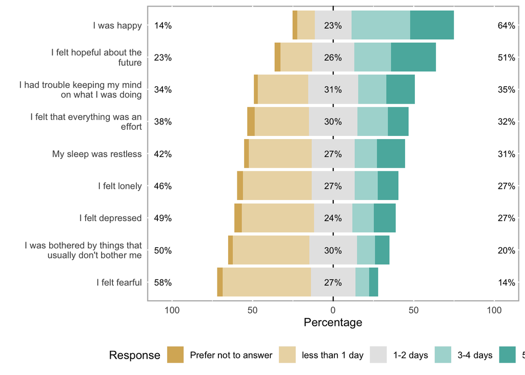

Vanguard Survey – Depression Questions, by Youth Arm variable  
Below is a list of the ways you might have felt or behaved. Please tell me how often you have felt this way during the past 7 days.

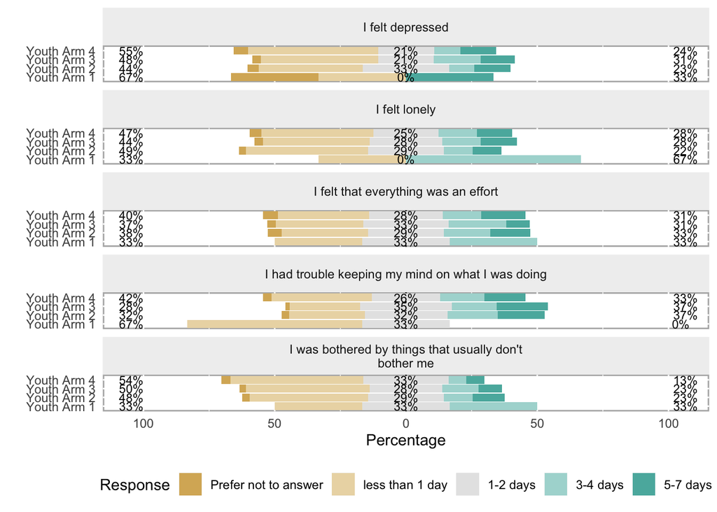

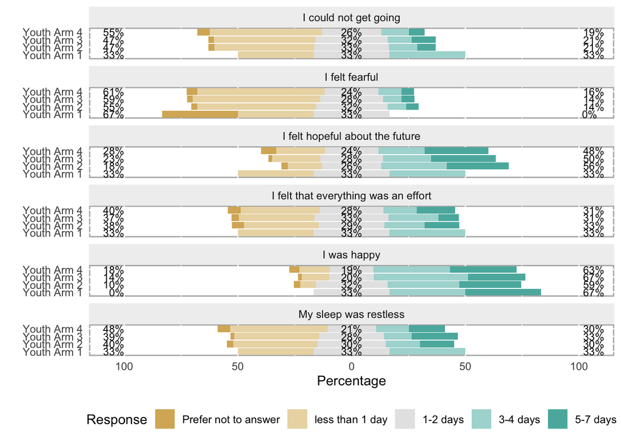

### Vanguard Tables

**I was bothered by things that usually don’t bother me**

| arm | 1-2 days | 3-4 days | 5-7 days | less than 1 day | Prefer not to answer | NA_ | Total |
| --- | --- | --- | --- | --- | --- | --- | --- |
| Youth Arm 1 | 1 (6.2%) | 1 (6.2%) | 0 (0.0%) | 1 (6.2%) | 0 (0.0%) | 13 (81.2%) | 16 (100.0%) |
| Youth Arm 2 | 21 (4.8%) | 8 (1.8%) | 9 (2.1%) | 33 (7.6%) | 2 (0.5%) | 361 (83.2%) | 434 (100.0%) |
| Youth Arm 3 | 34 (6.6%) | 17 (3.3%) | 11 (2.1%) | 58 (11.3%) | 3 (0.6%) | 391 (76.1%) | 514 (100.0%) |
| Youth Arm 4 | 29 (5.1%) | 6 (1.1%) | 6 (1.1%) | 45 (8.0%) | 3 (0.5%) | 475 (84.2%) | 564 (100.0%) |
| Total | 85 (5.6%) | 32 (2.1%) | 26 (1.7%) | 137 (9.0%) | 8 (0.5%) | 1240 (81.2%) | 1528 (100.0%) |

**I had trouble keeping my mind on what I was doing**

| arm | 1-2 days | 3-4 days | 5-7 days | less than 1 day | Prefer not to answer | NA_ | Total |
| --- | --- | --- | --- | --- | --- | --- | --- |
| Youth Arm 1 | 1 (6.2%) | 0 (0.0%) | 0 (0.0%) | 2 (12.5%) | 0 (0.0%) | 13 (81.2%) | 16 (100.0%) |
| Youth Arm 2 | 23 (5.3%) | 14 (3.2%) | 13 (3.0%) | 21 (4.8%) | 2 (0.5%) | 361 (83.2%) | 434 (100.0%) |
| Youth Arm 3 | 43 (8.4%) | 21 (4.1%) | 24 (4.7%) | 33 (6.4%) | 2 (0.4%) | 391 (76.1%) | 514 (100.0%) |
| Youth Arm 4 | 23 (4.1%) | 15 (2.7%) | 14 (2.5%) | 34 (6.0%) | 3 (0.5%) | 475 (84.2%) | 564 (100.0%) |
| Total | 90 (5.9%) | 50 (3.3%) | 51 (3.3%) | 90 (5.9%) | 7 (0.5%) | 1240 (81.2%) | 1528 (100.0%) |

**I felt lonely**

| arm | 1-2 days | 3-4 days | 5-7 days | less than 1 day | Prefer not to answer | NA_ | Total |
| --- | --- | --- | --- | --- | --- | --- | --- |
| Youth Arm 1 | 0 (0.0%) | 2 (12.5%) | 0 (0.0%) | 1 (6.2%) | 0 (0.0%) | 13 (81.2%) | 16 (100.0%) |
| Youth Arm 2 | 21 (4.8%) | 8 (1.8%) | 8 (1.8%) | 34 (7.8%) | 2 (0.5%) | 361 (83.2%) | 434 (100.0%) |
| Youth Arm 3 | 34 (6.6%) | 18 (3.5%) | 17 (3.3%) | 50 (9.7%) | 4 (0.8%) | 391 (76.1%) | 514 (100.0%) |
| Youth Arm 4 | 22 (3.9%) | 13 (2.3%) | 12 (2.1%) | 38 (6.7%) | 4 (0.7%) | 475 (84.2%) | 564 (100.0%) |
| Total | 77 (5.0%) | 41 (2.7%) | 37 (2.4%) | 123 (8.0%) | 10 (0.7%) | 1240 (81.2%) | 1528 (100.0%) |

**I felt depressed**

| arm | 1-2 days | 3-4 days | 5-7 days | less than 1 day | Prefer not to answer | NA_ | Total |
| --- | --- | --- | --- | --- | --- | --- | --- |
| Youth Arm 1 | 0 (0.0%) | 0 (0.0%) | 1 (6.2%) | 1 (6.2%) | 1 (6.2%) | 13 (81.2%) | 16 (100.0%) |
| Youth Arm 2 | 24 (5.5%) | 7 (1.6%) | 10 (2.3%) | 29 (6.7%) | 3 (0.7%) | 361 (83.2%) | 434 (100.0%) |
| Youth Arm 3 | 26 (5.1%) | 22 (4.3%) | 16 (3.1%) | 55 (10.7%) | 4 (0.8%) | 391 (76.1%) | 514 (100.0%) |
| Youth Arm 4 | 19 (3.4%) | 9 (1.6%) | 12 (2.1%) | 44 (7.8%) | 5 (0.9%) | 475 (84.2%) | 564 (100.0%) |
| Total | 69 (4.5%) | 38 (2.5%) | 39 (2.6%) | 129 (8.4%) | 13 (0.9%) | 1240 (81.2%) | 1528 (100.0%) |

**I felt that everything was an effort**

| arm | 1-2 days | 3-4 days | 5-7 days | less than 1 day | Prefer not to answer | NA_ | Total |
| --- | --- | --- | --- | --- | --- | --- | --- |
| Youth Arm 1 | 1 (6.2%) | 1 (6.2%) | 0 (0.0%) | 1 (6.2%) | 0 (0.0%) | 13 (81.2%) | 16 (100.0%) |
| Youth Arm 2 | 21 (4.8%) | 13 (3.0%) | 11 (2.5%) | 24 (5.5%) | 4 (0.9%) | 361 (83.2%) | 434 (100.0%) |
| Youth Arm 3 | 40 (7.8%) | 27 (5.3%) | 11 (2.1%) | 41 (8.0%) | 4 (0.8%) | 391 (76.1%) | 514 (100.0%) |
| Youth Arm 4 | 25 (4.4%) | 13 (2.3%) | 15 (2.7%) | 31 (5.5%) | 5 (0.9%) | 475 (84.2%) | 564 (100.0%) |
| Total | 87 (5.7%) | 54 (3.5%) | 37 (2.4%) | 97 (6.3%) | 13 (0.9%) | 1240 (81.2%) | 1528 (100.0%) |

**I felt hopeful about the future**

| arm | 1-2 days | 3-4 days | 5-7 days | less than 1 day | Prefer not to answer | NA_ | Total |
| --- | --- | --- | --- | --- | --- | --- | --- |
| Youth Arm 1 | 1 (6.2%) | 1 (6.2%) | 0 (0.0%) | 1 (6.2%) | 0 (0.0%) | 13 (81.2%) | 16 (100.0%) |
| Youth Arm 2 | 19 (4.4%) | 21 (4.8%) | 20 (4.6%) | 11 (2.5%) | 2 (0.5%) | 361 (83.2%) | 434 (100.0%) |
| Youth Arm 3 | 34 (6.6%) | 26 (5.1%) | 35 (6.8%) | 26 (5.1%) | 2 (0.4%) | 391 (76.1%) | 514 (100.0%) |
| Youth Arm 4 | 21 (3.7%) | 18 (3.2%) | 25 (4.4%) | 19 (3.4%) | 6 (1.1%) | 475 (84.2%) | 564 (100.0%) |
| Total | 75 (4.9%) | 66 (4.3%) | 80 (5.2%) | 57 (3.7%) | 10 (0.7%) | 1240 (81.2%) | 1528 (100.0%) |

**I felt fearful**

| arm | 1-2 days | 3-4 days | 5-7 days | less than 1 day | Prefer not to answer | NA_ | Total |
| --- | --- | --- | --- | --- | --- | --- | --- |
| Youth Arm 1 | 1 (6.2%) | 0 (0.0%) | 0 (0.0%) | 1 (6.2%) | 1 (6.2%) | 13 (81.2%) | 16 (100.0%) |
| Youth Arm 2 | 23 (5.3%) | 6 (1.4%) | 4 (0.9%) | 38 (8.8%) | 2 (0.5%) | 361 (83.2%) | 434 (100.0%) |
| Youth Arm 3 | 34 (6.6%) | 10 (1.9%) | 7 (1.4%) | 69 (13.4%) | 3 (0.6%) | 391 (76.1%) | 514 (100.0%) |
| Youth Arm 4 | 21 (3.7%) | 9 (1.6%) | 5 (0.9%) | 50 (8.9%) | 4 (0.7%) | 475 (84.2%) | 564 (100.0%) |
| Total | 79 (5.2%) | 25 (1.6%) | 16 (1.0%) | 158 (10.3%) | 10 (0.7%) | 1240 (81.2%) | 1528 (100.0%) |

**My sleep was restless**

| arm | 1-2 days | 3-4 days | 5-7 days | less than 1 day | Prefer not to answer | NA_ | Total |
| --- | --- | --- | --- | --- | --- | --- | --- |
| Youth Arm 1 | 1 (6.2%) | 1 (6.2%) | 0 (0.0%) | 1 (6.2%) | 0 (0.0%) | 13 (81.2%) | 16 (100.0%) |
| Youth Arm 2 | 22 (5.1%) | 11 (2.5%) | 11 (2.5%) | 27 (6.2%) | 2 (0.5%) | 361 (83.2%) | 434 (100.0%) |
| Youth Arm 3 | 35 (6.8%) | 15 (2.9%) | 25 (4.9%) | 46 (8.9%) | 2 (0.4%) | 391 (76.1%) | 514 (100.0%) |
| Youth Arm 4 | 19 (3.4%) | 13 (2.3%) | 14 (2.5%) | 38 (6.7%) | 5 (0.9%) | 475 (84.2%) | 564 (100.0%) |
| Total | 77 (5.0%) | 40 (2.6%) | 50 (3.3%) | 112 (7.3%) | 9 (0.6%) | 1240 (81.2%) | 1528 (100.0%) |

**I was happy**

| arm | 1-2 days | 3-4 days | 5-7 days | less than 1 day | Prefer not to answer | NA_ | Total |
| --- | --- | --- | --- | --- | --- | --- | --- |
| Youth Arm 1 | 1 (6.2%) | 1 (6.2%) | 1 (6.2%) | 0 (0.0%) | 0 (0.0%) | 13 (81.2%) | 16 (100.0%) |
| Youth Arm 2 | 23 (5.3%) | 23 (5.3%) | 20 (4.6%) | 5 (1.2%) | 2 (0.5%) | 361 (83.2%) | 434 (100.0%) |
| Youth Arm 3 | 24 (4.7%) | 51 (9.9%) | 31 (6.0%) | 15 (2.9%) | 2 (0.4%) | 391 (76.1%) | 514 (100.0%) |
| Youth Arm 4 | 17 (3.0%) | 30 (5.3%) | 26 (4.6%) | 12 (2.1%) | 4 (0.7%) | 475 (84.2%) | 564 (100.0%) |
| Total | 65 (4.3%) | 105 (6.9%) | 78 (5.1%) | 32 (2.1%) | 8 (0.5%) | 1240 (81.2%) | 1528 (100.0%) |

**I could not get going**

| arm | 1-2 days | 3-4 days | 5-7 days | less than 1 day | Prefer not to answer | NA_ | Total |
| --- | --- | --- | --- | --- | --- | --- | --- |
| Youth Arm 1 | 1 (6.2%) | 1 (6.2%) | 0 (0.0%) | 1 (6.2%) | 0 (0.0%) | 13 (81.2%) | 16 (100.0%) |
| Youth Arm 2 | 24 (5.5%) | 9 (2.1%) | 6 (1.4%) | 32 (7.4%) | 2 (0.5%) | 361 (83.2%) | 434 (100.0%) |
| Youth Arm 3 | 39 (7.6%) | 13 (2.5%) | 13 (2.5%) | 55 (10.7%) | 3 (0.6%) | 391 (76.1%) | 514 (100.0%) |
| Youth Arm 4 | 23 (4.1%) | 11 (2.0%) | 6 (1.1%) | 44 (7.8%) | 5 (0.9%) | 475 (84.2%) | 564 (100.0%) |
| Total | 87 (5.7%) | 34 (2.2%) | 25 (1.6%) | 132 (8.6%) | 10 (0.7%) | 1240 (81.2%) | 1528 (100.0%) |

### G2C graphs

**Below is a list of the ways you might have felt or behaved. Please tell me how often you have felt this way during the past 7 days.**

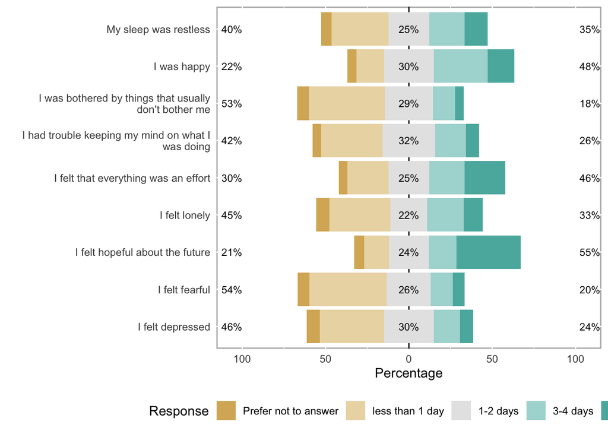

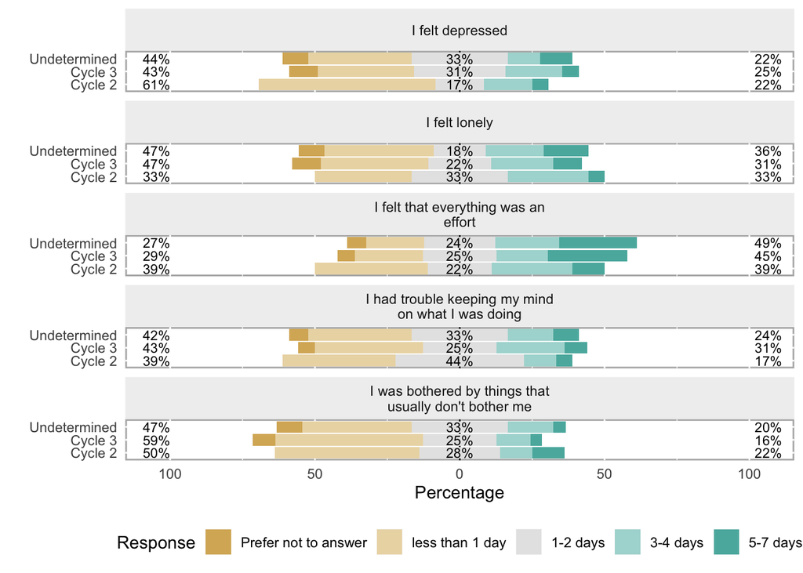

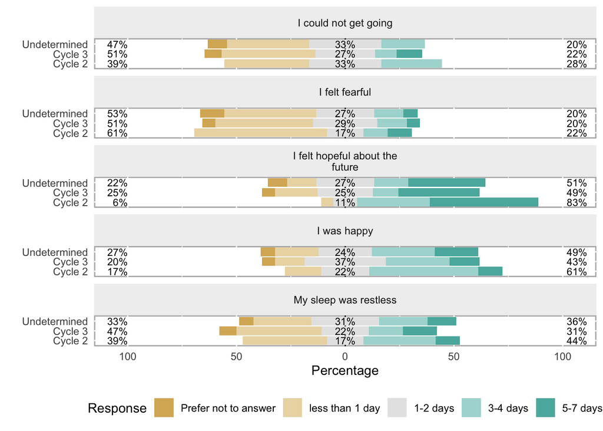

### G2C Tables

**I was bothered by things that usually don’t bother me**

| cycle1 | 1-2 days | 3-4 days | 5-7 days | less than 1 day | Prefer not to answer | Total |
| --- | --- | --- | --- | --- | --- | --- |
| Cycle 2 | 5 (27.8%) | 2 (11.1%) | 2 (11.1%) | 9 (50.0%) | 0 (0.0%) | 18 (100.0%) |
| Cycle 3 | 13 (25.5%) | 6 (11.8%) | 2 (3.9%) | 26 (51.0%) | 4 (7.8%) | 51 (100.0%) |
| Undetermined | 15 (33.3%) | 7 (15.6%) | 2 (4.4%) | 17 (37.8%) | 4 (8.9%) | 45 (100.0%) |
| Total | 33 (28.9%) | 15 (13.2%) | 6 (5.3%) | 52 (45.6%) | 8 (7.0%) | 114 (100.0%) |

**I had trouble keeping my mind on what I was doing**

| cycle1 | 1-2 days | 3-4 days | 5-7 days | less than 1 day | Prefer not to answer | Total |
| --- | --- | --- | --- | --- | --- | --- |
| Cycle 2 | 8 (44.4%) | 2 (11.1%) | 1 (5.6%) | 7 (38.9%) | 0 (0.0%) | 18 (100.0%) |
| Cycle 3 | 13 (25.5%) | 12 (23.5%) | 4 (7.8%) | 19 (37.3%) | 3 (5.9%) | 51 (100.0%) |
| Undetermined | 15 (33.3%) | 7 (15.6%) | 4 (8.9%) | 16 (35.6%) | 3 (6.7%) | 45 (100.0%) |
| Total | 36 (31.6%) | 21 (18.4%) | 9 (7.9%) | 42 (36.8%) | 6 (5.3%) | 114 (100.0%) |

**I felt lonely**

| cycle1 | 1-2 days | 3-4 days | 5-7 days | less than 1 day | Prefer not to answer | Total |
| --- | --- | --- | --- | --- | --- | --- |
| Cycle 2 | 6 (33.3%) | 5 (27.8%) | 1 (5.6%) | 6 (33.3%) | 0 (0.0%) | 18 (100.0%) |
| Cycle 3 | 11 (21.6%) | 11 (21.6%) | 5 (9.8%) | 19 (37.3%) | 5 (9.8%) | 51 (100.0%) |
| Undetermined | 8 (17.8%) | 9 (20.0%) | 7 (15.6%) | 17 (37.8%) | 4 (8.9%) | 45 (100.0%) |
| Total | 25 (21.9%) | 25 (21.9%) | 13 (11.4%) | 42 (36.8%) | 9 (7.9%) | 114 (100.0%) |

**I felt depressed**

| cycle1 | 1-2 days | 3-4 days | 5-7 days | less than 1 day | Prefer not to answer | Total |
| --- | --- | --- | --- | --- | --- | --- |
| Cycle 2 | 3 (16.7%) | 3 (16.7%) | 1 (5.6%) | 11 (61.1%) | 0 (0.0%) | 18 (100.0%) |
| Cycle 3 | 16 (31.4%) | 10 (19.6%) | 3 (5.9%) | 17 (33.3%) | 5 (9.8%) | 51 (100.0%) |
| Undetermined | 15 (33.3%) | 5 (11.1%) | 5 (11.1%) | 16 (35.6%) | 4 (8.9%) | 45 (100.0%) |
| Total | 34 (29.8%) | 18 (15.8%) | 9 (7.9%) | 44 (38.6%) | 9 (7.9%) | 114 (100.0%) |

**I felt that everything was an effort**

| cycle1 | 1-2 days | 3-4 days | 5-7 days | less than 1 day | Prefer not to answer | Total |
| --- | --- | --- | --- | --- | --- | --- |
| Cycle 2 | 4 (22.2%) | 5 (27.8%) | 2 (11.1%) | 7 (38.9%) | 0 (0.0%) | 18 (100.0%) |
| Cycle 3 | 13 (25.5%) | 9 (17.6%) | 14 (27.5%) | 12 (23.5%) | 3 (5.9%) | 51 (100.0%) |
| Undetermined | 11 (24.4%) | 10 (22.2%) | 12 (26.7%) | 9 (20.0%) | 3 (6.7%) | 45 (100.0%) |
| Total | 28 (24.6%) | 24 (21.1%) | 28 (24.6%) | 28 (24.6%) | 6 (5.3%) | 114 (100.0%) |

**I felt hopeful about the future**

| cycle1 | 1-2 days | 3-4 days | 5-7 days | less than 1 day | Prefer not to answer | Total |
| --- | --- | --- | --- | --- | --- | --- |
| Cycle 2 | 2 (11.1%) | 6 (33.3%) | 9 (50.0%) | 1 (5.6%) | 0 (0.0%) | 18 (100.0%) |
| Cycle 3 | 13 (25.5%) | 6 (11.8%) | 19 (37.3%) | 10 (19.6%) | 3 (5.9%) | 51 (100.0%) |
| Undetermined | 12 (26.7%) | 7 (15.6%) | 16 (35.6%) | 6 (13.3%) | 4 (8.9%) | 45 (100.0%) |
| Total | 27 (23.7%) | 19 (16.7%) | 44 (38.6%) | 17 (14.9%) | 7 (6.1%) | 114 (100.0%) |

**I felt fearful**

| cycle1 | 1-2 days | 3-4 days | 5-7 days | less than 1 day | Prefer not to answer | Total |
| --- | --- | --- | --- | --- | --- | --- |
| Cycle 2 | 3 (16.7%) | 2 (11.1%) | 2 (11.1%) | 11 (61.1%) | 0 (0.0%) | 18 (100.0%) |
| Cycle 3 | 15 (29.4%) | 7 (13.7%) | 3 (5.9%) | 23 (45.1%) | 3 (5.9%) | 51 (100.0%) |
| Undetermined | 12 (26.7%) | 6 (13.3%) | 3 (6.7%) | 19 (42.2%) | 5 (11.1%) | 45 (100.0%) |
| Total | 30 (26.3%) | 15 (13.2%) | 8 (7.0%) | 53 (46.5%) | 8 (7.0%) | 114 (100.0%) |

**My sleep was restless**

| cycle1 | 1-2 days | 3-4 days | 5-7 days | less than 1 day | Prefer not to answer | Total |
| --- | --- | --- | --- | --- | --- | --- |
| Cycle 2 | 3 (16.7%) | 6 (33.3%) | 2 (11.1%) | 7 (38.9%) | 0 (0.0%) | 18 (100.0%) |
| Cycle 3 | 11 (21.6%) | 8 (15.7%) | 8 (15.7%) | 20 (39.2%) | 4 (7.8%) | 51 (100.0%) |
| Undetermined | 14 (31.1%) | 10 (22.2%) | 6 (13.3%) | 12 (26.7%) | 3 (6.7%) | 45 (100.0%) |
| Total | 28 (24.6%) | 24 (21.1%) | 16 (14.0%) | 39 (34.2%) | 7 (6.1%) | 114 (100.0%) |

**I was happy**

| cycle1 | 1-2 days | 3-4 days | 5-7 days | less than 1 day | Prefer not to answer | Total |
| --- | --- | --- | --- | --- | --- | --- |
| Cycle 2 | 4 (22.2%) | 9 (50.0%) | 2 (11.1%) | 3 (16.7%) | 0 (0.0%) | 18 (100.0%) |
| Cycle 3 | 19 (37.3%) | 15 (29.4%) | 7 (13.7%) | 7 (13.7%) | 3 (5.9%) | 51 (100.0%) |
| Undetermined | 11 (24.4%) | 13 (28.9%) | 9 (20.0%) | 9 (20.0%) | 3 (6.7%) | 45 (100.0%) |
| Total | 34 (29.8%) | 37 (32.5%) | 18 (15.8%) | 19 (16.7%) | 6 (5.3%) | 114 (100.0%) |

**I could not get going**

| cycle1 | 1-2 days | 3-4 days | 5-7 days | less than 1 day | Prefer not to answer | Total |
| --- | --- | --- | --- | --- | --- | --- |
| Cycle 2 | 6 (33.3%) | 5 (27.8%) | 0 (0.0%) | 7 (38.9%) | 0 (0.0%) | 18 (100.0%) |
| Cycle 3 | 14 (27.5%) | 5 (9.8%) | 6 (11.8%) | 22 (43.1%) | 4 (7.8%) | 51 (100.0%) |
| Undetermined | 15 (33.3%) | 9 (20.0%) | 0 (0.0%) | 17 (37.8%) | 4 (8.9%) | 45 (100.0%) |
| Total | 35 (30.7%) | 19 (16.7%) | 6 (5.3%) | 46 (40.4%) | 8 (7.0%) | 114 (100.0%) |

### Vanguard vs. G2C

**Please answer the following questions based on how you felt in the past 7 days.**

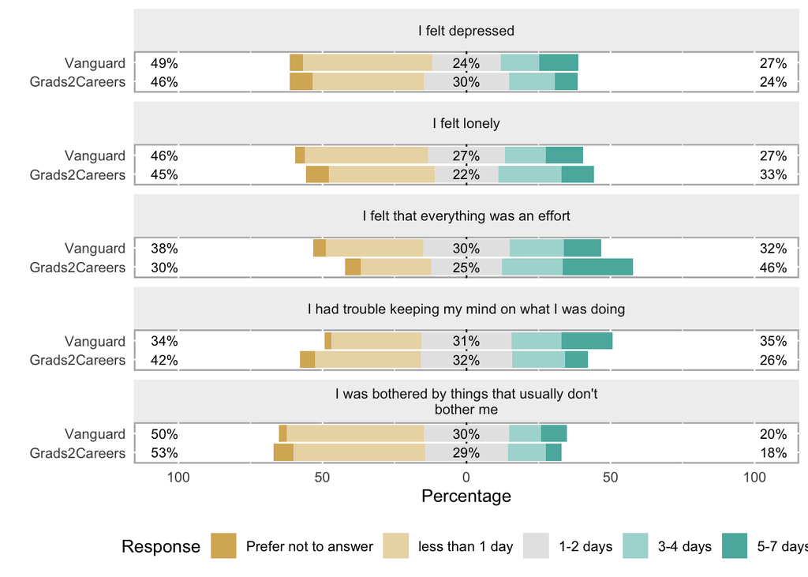

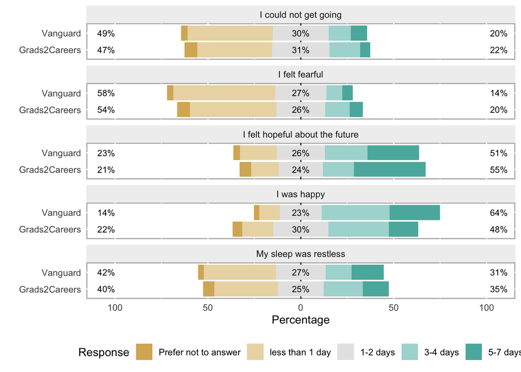

**Histogram of Depression Scores (total of 10 variables, range:0-30): Vanguard vs. G2C**

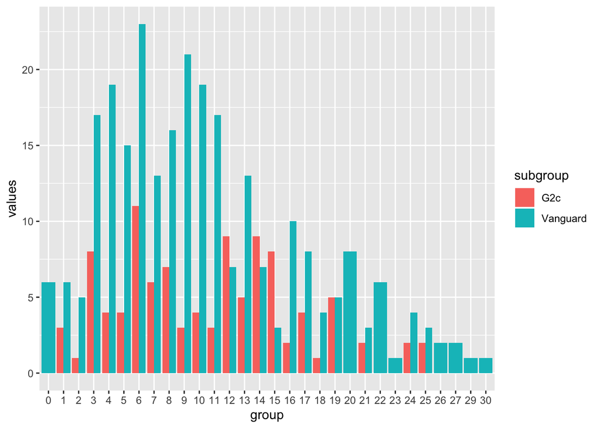

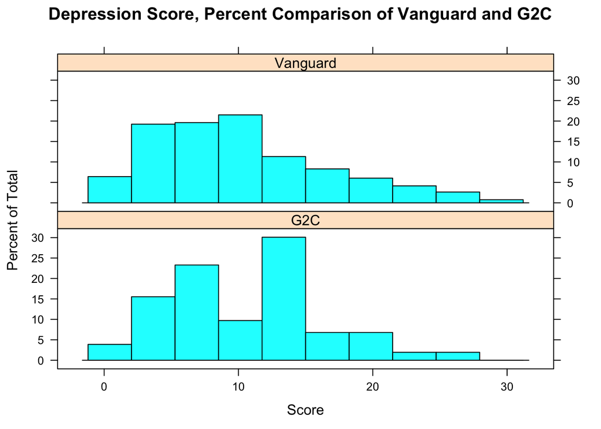

```
##
##  Wilcoxon rank sum test with continuity correction
##
## data:  depression_total_merged$depression_total_no_refused by depression_total_merged$study
## W = 14632, p-value = 0.2821
## alternative hypothesis: true location shift is not equal to 0
```

```
##
##  Welch Two Sample t-test
##
## data:  depression_total_merged$depression_total_no_refused by depression_total_merged$study
## t = 0.64437, df = 207.35, p-value = 0.52
## alternative hypothesis: true difference in means is not equal to 0
## 95 percent confidence interval:
##  -0.9222785  1.8179004
## sample estimates:
##      mean in group G2C mean in group Vanguard
##               10.68932               10.24151
```

Depression score comparison

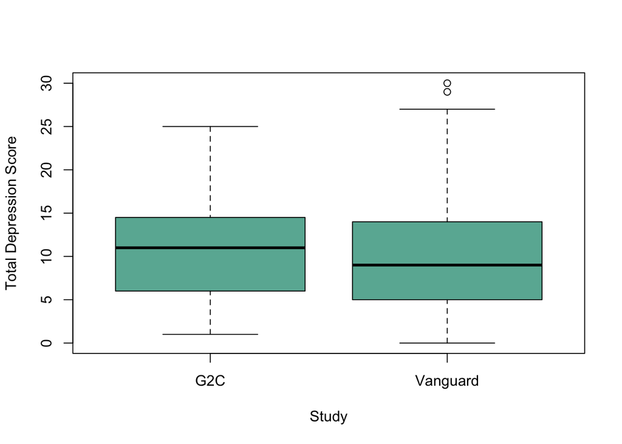